# Net Benefit Calculations

Gary E. Weissman, MD, MSHP

6/24/2020

## Background

The goal of this study is to determine when it would be worthwhile to do the work to determine utilities for predicted outcomes (e.g. false positive vs false negative errors) and when using a net-benefit approach would give equivalent results.

Note that net benefit analysis (Vickers MDM 2006) is *not* meant to be used for bedside decision making, and is *not* meant to determine a threshold. Rather, a range of thresholds are meant to be determined using clinical judgement and the decision curve is meant to inform which models are optimal over those ranges. See Vicker’s clarification here: https://doi.org/10.1186/s41512-019-0064-7

While this approach is *easier* than doing the work of obtaining end-user utilities, it conflates the part-worth utilities of different outcomes with an optimal classification threshold. Therefore we seek to see to what degree model outcomes are imbalanced would yield different interpretations of optimal models.

Also consider that the classification threshold has an impact of fairness. Note that estimation of utilities may also lead to different stakeholders having divergent weights, and thus may prefer different models.

## Data

Using the HIRID case study, build a prediction model and choose the “best” using DCA. Then *weight* the benefits and see if we get the same answers.

```r
library(data.table)
library(R.utils)
```

```r
library(ggplot2)
library(caret)
library(gmish)
library(ggsci)
library(table1)
library(patchwork)
library(cowplot)
library(MASS)
library(xgboost)
library(naivebayes)
library(doFuture)
registerDoFuture()
plan(multisession, workers = availableCores() - 1)
set.seed(24601)
```

## Case study 1: Predicting vent need in the ICU

Predict need for mechanical ventilation (vm62) since mortality is apparently not available based on the first 24 hours of clinical data in the HIRID dataset. Exclude patients intubated within the first 24 hours. See data dictionary here: https://hirid.intensivecare.ai/Data-details-1ff9c433b9894904b1dbd7652be4b11c

```r
fname_lst <- list.files('/data/hirid_v1.0/merged_stage/merged_stage/csv/', full.names = TRUE)
hirid_dt <- rbindlist(lapply(fname_lst, fread))

# Use these vars
var_names <- c(patientid = 'patientid', datetime = 'datetime',
               vm1 = 'heart_rate', vm3 = 'sbp_invasive', vm20 = 'spo2',
               vm28 = 'rass', vm62 = 'pip', vm146 = 'lactate_venous',
               vm172 = 'inr', vm174 = 'glucose_serum')
hirid_dt <- hirid_dt[, names(var_names), with = FALSE]
setnames(hirid_dt, var_names)

# Create some helpful features
hirid_dt[, datetime_dt := as.POSIXct(datetime)]
hirid_dt[, first_record := min(datetime_dt), by = patientid]
hirid_dt[, last_record := max(datetime_dt), by = patientid]
hirid_dt[, in_first_24h := as.numeric(datetime_dt - first_record,
                                      units = 'hours') <= 24 , by = patientid]
hirid_dt[, los_hrs := as.numeric(last_record - first_record,
                                 units = 'hours'), by = patientid]

# Remove observations with LOS < 24h
hirid_dt <- hirid_dt[los_hrs >= 24]

# generate the outcome variable for ever on the vent
hirid_dt[, ever_on_vent := as.numeric(any(! is.na(pip))), by = patientid]
y_dt <- unique(hirid_dt[, .(patientid, ever_on_vent)])

# Drop everything outside of first 24 h
hirid_dt <- hirid_dt[in_first_24h == TRUE]

# Now get worst value in first 24h
hirid_worst24_dt <- hirid_dt[, .(hr_highest = max(heart_rate, na.rm = TRUE),
                                 hr_sd = sd(heart_rate, na.rm = TRUE),
                                 sbp_lowest = min(sbp_invasive, na.rm = TRUE),
                                 sbp_sd = sd(sbp_invasive, na.rm = TRUE),
                                 spo2_lowest = min(spo2, na.rm = TRUE),
                                 spo2_sd = sd(spo2, na.rm = TRUE),
                                 rass_lowest = min(rass, na.rm = TRUE),
                                 rass_sd = sd(rass, na.rm = TRUE),
                                 glucose_lowest = min(glucose_serum, na.rm = TRUE),
                                 glucose_sd = sd(glucose_serum, na.rm = TRUE),
                                 lactate_highest = max(lactate_venous, na.rm = TRUE),
                                 lactate_highest_sd = sd(lactate_venous, na.rm = TRUE),
                                 inr_highest = max(inr, na.rm = TRUE),
                                 inr_highest_sd = sd(inr, na.rm = TRUE),
                                 on_vent_within_24h = any(! is.na(pip))),
                             by = patientid]
# Remove observations where patient was intubated in first 24h
hirid_worst24_dt <- hirid_worst24_dt[on_vent_within_24h == FALSE]


# Now just median impute any missing
hirid_worst24_dt <- as.data.table(lapply(hirid_worst24_dt, function(col) {
  col[is.na(col) | is.infinite(col)] <- median(col[is.finite(col)], na.rm = TRUE)
  return(col)
}))

# Merge back with outcomes
hirid_worst24_dt <- merge(hirid_worst24_dt, y_dt, by = 'patientid', all.x = TRUE)
#merge for sex and age
general_dt <- fread('/data/hirid_v1.0/general_table.csv')
general_dt <- general_dt[,c(1,3,4)]
hirid_worst24_dt <- merge(hirid_worst24_dt, general_dt, by = 'patientid', all.x = TRUE)

# Check no missingness
summary(hirid_worst24_dt)
```

```
##    patientid       hr_highest        hr_sd          sbp_lowest
##  Min.   :    2   Min.   : 38.0   Min.   : 0.000   Min.   : 10.00
##  1st Qu.: 8623   1st Qu.: 95.0   1st Qu.: 5.185   1st Qu.: 78.00
##  Median :16961   Median :106.0   Median : 6.781   Median : 91.00
##  Mean   :16966   Mean   :109.6   Mean   : 7.354   Mean   : 90.84
##  3rd Qu.:25422   3rd Qu.:119.0   3rd Qu.: 8.774   3rd Qu.:103.00
##  Max.   :33903   Max.   :300.0   Max.   :55.815   Max.   :214.00
##      sbp_sd       spo2_lowest        spo2_sd        rass_lowest
##  Min.   : 0.00   Min.   : 10.00   Min.   : 0.000   Min.   :-5.000
##  1st Qu.:10.19   1st Qu.: 83.00   1st Qu.: 1.245   1st Qu.:-1.000
##  Median :12.35   Median : 89.00   Median : 1.569   Median :-1.000
##  Mean   :12.82   Mean   : 87.37   Mean   : 1.707   Mean   :-1.179
##  3rd Qu.:14.80   3rd Qu.: 92.30   3rd Qu.: 1.962   3rd Qu.:-1.000
##  Max.   :88.39   Max.   :100.00   Max.   :15.548   Max.   : 4.000
##     rass_sd       glucose_lowest     glucose_sd      lactate_highest
##  Min.   :0.0000   Min.   : 0.700   Min.   : 0.0000   Min.   : 0.400
##  1st Qu.:0.4629   1st Qu.: 5.700   1st Qu.: 0.6532   1st Qu.: 1.600
##  Median :0.5130   Median : 6.400   Median : 0.9215   Median : 1.600
##  Mean   :0.5837   Mean   : 6.628   Mean   : 1.1366   Mean   : 1.621
##  3rd Qu.:0.6293   3rd Qu.: 7.200   3rd Qu.: 1.2806   3rd Qu.: 1.600
##  Max.   :4.2426   Max.   :50.050   Max.   :14.6993   Max.   :10.700
##  lactate_highest_sd  inr_highest    inr_highest_sd    on_vent_within_24h
##  Min.   :0.0000     Min.   :1.000   Min.   :0.00000   Mode :logical
##  1st Qu.:0.2646     1st Qu.:1.100   1st Qu.:0.04243   FALSE:15213
##  Median :0.2646     Median :1.100   Median :0.04243
##  Mean   :0.2661     Mean   :1.157   Mean   :0.04799
##  3rd Qu.:0.2646     3rd Qu.:1.100   3rd Qu.:0.04243
##  Max.   :3.8184     Max.   :6.630   Max.   :2.89982
##   ever_on_vent        sex                 age
##  Min.   :0.0000   Length:15213       Min.   :20.00
##  1st Qu.:0.0000   Class :character   1st Qu.:55.00
##  Median :0.0000   Mode  :character   Median :65.00
##  Mean   :0.1265                      Mean   :62.53
##  3rd Qu.:0.0000                      3rd Qu.:75.00
##  Max.   :1.0000                      Max.   :90.00
```

```r
# Remove initial dt to save some memory for training
rm(hirid_dt)
gc()
```

```
##           used  (Mb) gc trigger    (Mb)    max used    (Mb)
## Ncells 2514412 134.3    4024045   215.0     4024045   215.0
## Vcells 4698096  35.9 8422664450 64259.9 10352461047 78983.1
```

```r
# Split into train and test
idx_train <- sample(nrow(hirid_worst24_dt),
                    size = round(0.8 * nrow(hirid_worst24_dt)),
                    replace = FALSE)
```

Summarize the data.

```r
table1(~ factor(sex) + age + on_vent_within_24h, data =  hirid_worst24_dt)
```

|  | Overall (N=15213) |
| --- | --- |
| factor(sex) |  |
| F | 6125 (40.3%) |
| M | 9088 (59.7%) |
| age |  |
| Mean (SD) | 62.5 (15.7) |
| Median [Min, Max] | 65.0 [20.0, 90.0] |
| on_vent_within_24h |  |
| Yes | 0 (0%) |
| No | 15213 (100%) |

```r
table1(~ factor(sex) + age + on_vent_within_24h | dataset, data =  data.table(hirid_worst24_dt,
                                                                    dataset = ifelse(seq_along(1:nrow(hirid_worst24_dt)) %in% idx_train, 'train', 'test')))
```

|  | test (N=3043) | train (N=12170) | Overall (N=15213) |
| --- | --- | --- | --- |
| factor(sex) |  |  |  |
| F | 1232 (40.5%) | 4893 (40.2%) | 6125 (40.3%) |
| M | 1811 (59.5%) | 7277 (59.8%) | 9088 (59.7%) |
| age |  |  |  |
| Mean (SD) | 62.7 (15.7) | 62.5 (15.7) | 62.5 (15.7) |
| Median [Min, Max] | 65.0 [20.0, 90.0] | 65.0 [20.0, 90.0] | 65.0 [20.0, 90.0] |
| on_vent_within_24h |  |  |  |
| Yes | 0 (0%) | 0 (0%) | 0 (0%) |
| No | 3043 (100%) | 12170 (100%) | 15213 (100%) |

```r
# Remove other vars not for  prediction
hirid_worst24_dt[, on_vent_within_24h := NULL]
```

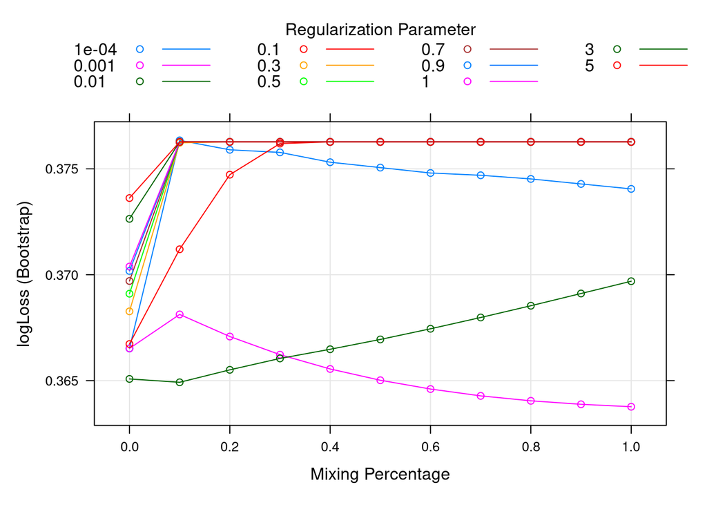

```r
my_control <- trainControl(method = "boot",
                           number = 100,
                           classProbs = TRUE,
                           returnData = TRUE,
                           returnResamp = 'all',
                           savePredictions = TRUE,
                           summaryFunction = mnLogLoss)

# ------------------- Train elastic net model
grid_en <- expand.grid(alpha = seq(0,1,.1),
                       lambda = c(0.0001, 0.001, 0.01, 0.1, 0.3, 0.5, 0.7, 0.9, 1, 3, 5))

mod_hirid_en <- caret::train(as.factor(make.names(ever_on_vent)) ~ .^2, # include interaction terms
                      method = 'glmnet',
                      family = 'binomial',
                      trControl = my_control,
                      tuneGrid = grid_en,
                      metric = 'logLoss',
                      data = hirid_worst24_dt[idx_train, -1])

preds_hirid_en <- predict(mod_hirid_en, newdata = hirid_worst24_dt[-idx_train], type = 'prob')[,2]
plot(mod_hirid_en)
```

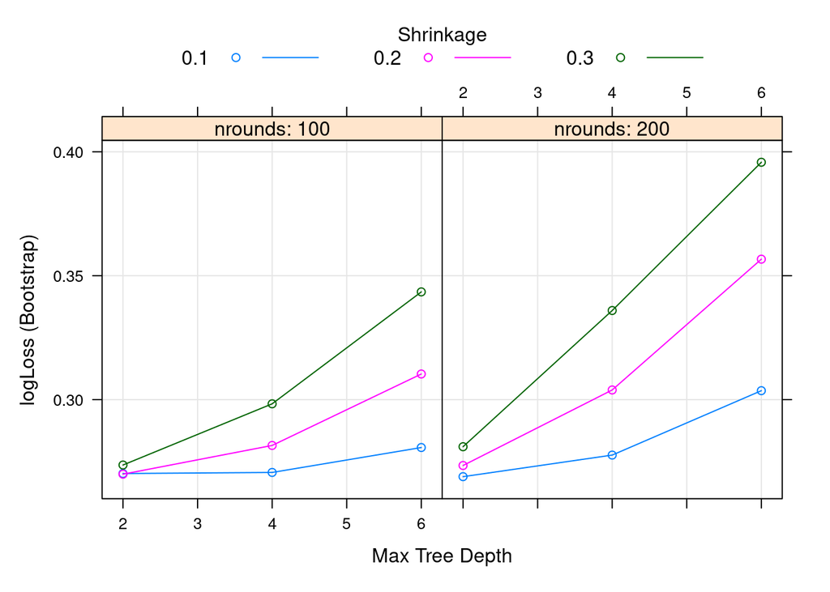

```r
# ------------------- Train XGB model
grid_xgb <- expand.grid(nrounds = c(100, 200),
                        max_depth = 1:3 * 2,
                        eta = c(0.3, 0.2, 0.1),
                        gamma = 0,
                        colsample_bytree = 1,
                        min_child_weight = 1,
                        subsample = c(1))

mod_hirid_xgb <- train(as.factor(make.names(ever_on_vent)) ~ .^2,
                    method = 'xgbTree',
                    trControl = my_control,
                    tuneGrid = grid_xgb,
                    metric = 'logLoss',
                    data = hirid_worst24_dt[idx_train,-1], verbosity = 0)
preds_hirid_xgb <- predict(mod_hirid_xgb, newdata = hirid_worst24_dt[-idx_train], type = 'prob')[,2]
plot(mod_hirid_xgb)
```

```r
# ------------------- Train SVM model
grid_svm <- expand.grid(C = seq(0, 2, length = 10))

mod_hirid_svm <- train(as.factor(make.names(ever_on_vent)) ~ .^2,
                       method = "svmLinear",
                       trControl = my_control,
                       tuneGrid = grid_svm,
                       preProcess = c("center","scale"),
                        metric = 'logLoss',
                       data = hirid_worst24_dt[idx_train,-1], verbosity = 0)

preds_hirid_svm <- predict(mod_hirid_svm, newdata = hirid_worst24_dt[-idx_train], type = 'prob')[,2]
plot(mod_hirid_svm)
```

[output not shown]

```r
#fwrite(preds_hirid_en, 'output/preds_hirid_en.csv.gz')
#fwrite(preds_hirid_xgb, 'output/preds_hirid_xgb.csv.gz')
#fwrite(preds_hirid_svm, 'output/preds_hirid_svm.csv.gz')
#save(mod_hirid_en, mod_hirid_xgb, mod_hirid_svm, file = 'output/hirid_model_objects.RData')
```

```r
# ------------------- Train XGB model

grid_naive <- expand.grid(usekernel = c(TRUE, FALSE),
                         laplace = c(0, 0.3, 0.5, 0.8, 1),
                         adjust = c(0.25, 0.50, 0.75, 1, 1.25, 1.5, 1.75, 2.0))

mod_hirid_naive <- train(as.factor(make.names(ever_on_vent)) ~ .,
                      method = 'naive_bayes',
                      trControl = my_control,
                      tuneGrid = grid_naive,
                      usepoisson = TRUE,
                      metric = 'logLoss',
                      data = hirid_worst24_dt[idx_train,-1])
```

[figure not shown]

```r
preds_hirid_naive <- predict(mod_hirid_naive, newdata = hirid_worst24_dt[-idx_train], type = 'prob')[,2]
plot(mod_hirid_naive)
```

Look at performance of the models.

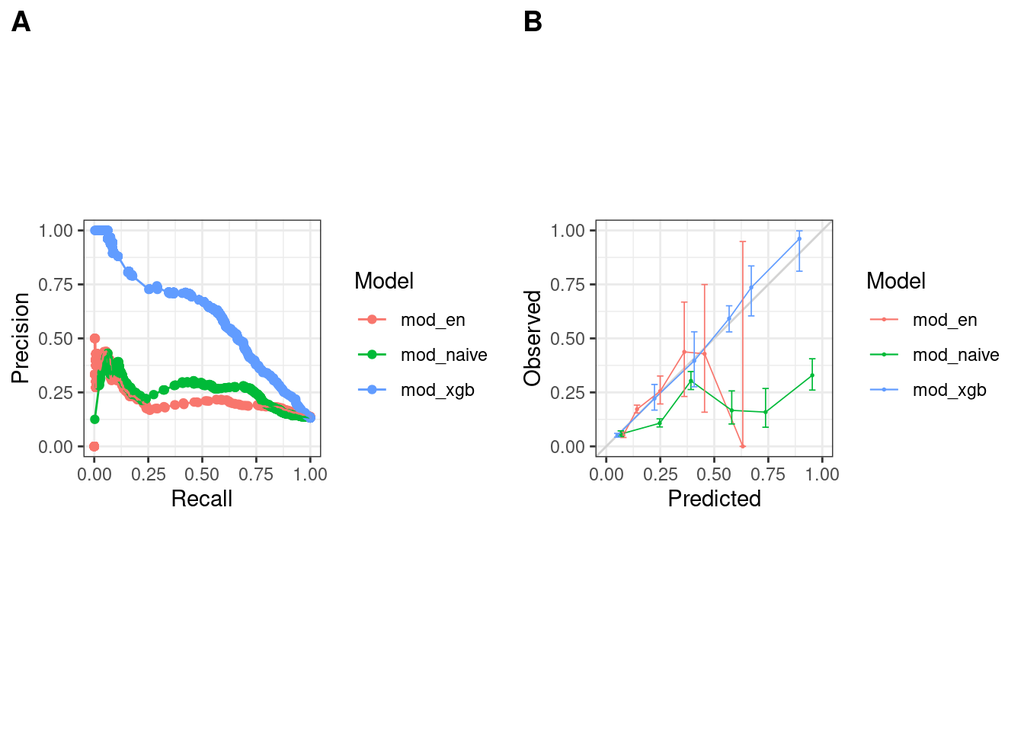

```r
hirid_res <- data.table(vented = hirid_worst24_dt[-idx_train]$ever_on_vent,
                        mod_en = preds_hirid_en,
                        mod_naive = preds_hirid_naive,
                        #mod_svm = preds_hirid_svm,
                        mod_xgb = preds_hirid_xgb)
fwrite(hirid_res, 'output/hirid_test_predictions.csv.gz')

# Calibration plot
cal_pl <- calib_plot(vented ~ mod_en + mod_naive  + mod_xgb,
                     data = hirid_res, cuts = 6) #+ mod_naive #, rug = TRUE
pr_pl <- pr_plot(vented ~ mod_en + mod_naive + mod_xgb, data = hirid_res)

library(cowplot)
plot_grid(pr_pl, cal_pl, labels = "AUTO")
```

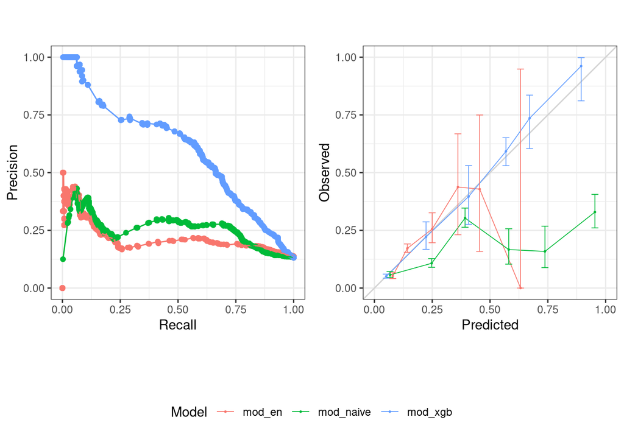

```r
cowplot::plot_grid(
   cowplot::plot_grid(
    pr_pl + scale_color_discrete(guide = FALSE),
    cal_pl + scale_color_discrete(guide = FALSE),
    ncol = 2, align = "v"
   ),
   cowplot::get_legend(cal_pl + scale_shape(guide = FALSE) +
      theme(legend.position = "bottom")),
   ncol=1, rel_heights=c(.85, .15))
```

```r
   ggsave('exhibits/fig_hirid_perf_all.png', width = 12, height = 7, dpi = 600)

# AUC
print(paste('AUC for the EN model: ', cstat(preds_hirid_en, hirid_worst24_dt[-idx_train]$ever_on_vent)))
```

```
## [1] "AUC for the EN model:  0.664340711312902"
```

```r
print(paste('AUC for the Naive Bayes model: ', cstat(preds_hirid_naive, hirid_worst24_dt[-idx_train]$ever_on_vent)))
```

```
## [1] "AUC for the Naive Bayes model:  0.712532160423761"
```

```r
#print(paste('AUC for the SVM model: ', cstat(preds_hirid_svm, hirid_worst24_dt[-idx_train]$ever_on_vent)))
print(paste('AUCfor the XGBoost model: ', cstat(preds_hirid_xgb, hirid_worst24_dt[-idx_train]$ever_on_vent)))
```

```
## [1] "AUCfor the XGBoost model:  0.859951759364359"
```

```r
# Scaled brier score
print(paste('Scaled brier score for the EN model: ',  sbrier(preds_hirid_en, hirid_worst24_dt[-idx_train]$ever_on_vent)))
```

```
## [1] "Scaled brier score for the EN model:  0.0346375687999273"
```

```r
print(paste('Scaled brier score for the Naive Bayes model: ',  sbrier(preds_hirid_naive, hirid_worst24_dt[-idx_train]$ever_on_vent)))
```

```
## [1] "Scaled brier score for the Naive Bayes model:  -0.28040789987298"
```

```r
#print(paste('Scaled brier score SVM model: ', sbrier(preds_hirid_svm, hirid_worst24_dt[-idx_train]$ever_on_vent)))
print(paste('Scaled brier score for the XGB model: ',  sbrier(preds_hirid_xgb, hirid_worst24_dt[-idx_train]$ever_on_vent)))
```

```
## [1] "Scaled brier score for the XGB model:  0.332647867258422"
```

```r
# logloss
print(paste('loglossfor the EN model: ', lloss(preds_hirid_en, hirid_worst24_dt[-idx_train]$ever_on_vent)))
```

```
## [1] "loglossfor the EN model:  0.370539708741299"
```

```r
print(paste('logloss for the Naive Bayes model: ', lloss(preds_hirid_naive, hirid_worst24_dt[-idx_train]$ever_on_vent)))
```

```
## [1] "logloss for the Naive Bayes model:  0.667705243977284"
```

```r
#print(paste('logloss for the SVM model: ', lloss(preds_hirid_svm, hirid_worst24_dt[-idx_train]$ever_on_vent)))
print(paste('logloss for the XGBoost model: ', lloss(preds_hirid_xgb, hirid_worst24_dt[-idx_train]$ever_on_vent)))
```

```
## [1] "logloss for the XGBoost model:  0.26453292129999"
```

Now compare the decision analysis curves.

```r
# This plotting approach is DEPRECATED -- see the next notebook for the definitive approach

# Set range of weights
weight_list <- c(1/8, 1/7, 1/6, 1/5, 1/4, 1/3, 1/2, 1, 2, 3, 4, 5, 6, 7, 8)
dca_list <- lapply(weight_list, function(w) {
  nb_plot(vented ~ mod_en + mod_naive + mod_xgb, weight = w,
                     data = hirid_res) +
    theme(legend.position="none") +
                     ggtitle(paste0('Weight: ', fractions(w))) +
    theme(text = element_text(size = 10))
})
# Collect legends with cowplot: https://wilkelab.org/cowplot/articles/shared_legends.html
# extract the legend from one of the plots
legend <- get_legend(
  # create some space to the left of the legend
  dca_list[[1]] + theme(legend.position = "bottom")
)
pg <- plot_grid(plotlist = dca_list,
          ncol = 5, align = "hv")
plot_grid(pg, legend, ncol = 1, rel_heights = c(1, .1))

# Patchwork not formatting well
# Reduce(f = `+`,
#       x = dca_list) + plot_layout(nrow = 3,
#                                   guides = "collect")  & theme(legend.position = 'bottom')

ggsave('exhibits/fig_hirid_dca_all.png', width = 12, height = 12, dpi = 600)
```

[output not shown]

```r
plan(sequential)
```